# Danish Kings

Smilla

5 Marts 2025

## Load the kings

1. Look at the dataset that are you loading and check what its columns are separated by? (hint: open it in plain text editor to see)

List what is the

separator:Comma (csv)

2. Create a `kings` object in R with the different functions below and inspect the different outputs.
- `read.csv()`
- `read_csv()`
- `read.csv2()`
- `read_csv2()`

```r
# FILL IN THE CODE BELOW and review the outputs
library(tidyverse)
kings1 <- read.csv("data/konger.csv")

kings2 <- read_csv("data/konger.csv")
kings3 <- read.csv2("data/konger.csv")

kings4 <- read_csv2("data/konger.csv")
```

```
## ℹ Using "','" as decimal and "'.'" as grouping mark. Use `read_delim()` for more control.
```

Answer: 1. Which of these functions is a `tidyverse` function? Read data with it below into a `kings` object Konger 2 og Konger 4, forskellen er de to er underscore csv, og ikke dot csv.

2. What is the result of running `class()` on the `kings` object created with a tidyverse function.

Man finder ud af, at navn og titel er karaktere (chr) og kolonnerne såsom regeringperiode_start_aar, osv. er tal (dbl).

3. How many columns does the object have when created with these different functions? konger 1 har 6 konger 2 har 6 konger 3 har 1 konger 4 har 1
4. Show the dataset so that we can see how R interprets each column: funktionen head viser hvordan R læser kolonnerne.

```r
# COMPLETE THE BLANKS BELOW WITH YOUR CODE, then turn the 'eval' flag in this chunk to TRUE.
library(tidyverse)
konger <- read_csv("data/konger.csv")
konger1 <- read.csv("data/konger.csv")
konger2 <- read_csv("data/konger.csv")
konger3 <- read.csv2("data/konger.csv")
konger4 <- read_csv2("data/konger.csv")
```

```
## ℹ Using "','" as decimal and "'.'" as grouping mark. Use `read_delim()` for more control.
```

```r
class(konger1)
```

```
## [1] "data.frame"
```

```r
class(konger2)
```

```
## [1] "spec_tbl_df" "tbl_df"      "tbl"         "data.frame"
```

```r
class(konger3)
```

```
## [1] "data.frame"
```

```r
class(konger4)
```

```
## [1] "spec_tbl_df" "tbl_df"      "tbl"         "data.frame"
```

```r
ncol(konger1)
```

```
## [1] 6
```

```r
ncol(konger2)
```

```
## [1] 6
```

```r
ncol(konger3)
```

```
## [1] 1
```

```r
ncol(konger4)
```

```
## [1] 1
```

```r
head(konger1)
```

```
##        Navn        Titel Regerinsperiode_start_aar Regeringsperiode_slut_aar
## 1      Gorm    Den_Gamle                       936                       958
## 2    Harald  1._Blaatand                       958                       987
## 3     Svend  1._Tveskaeg                       987                      1014
## 4    Harald          2._                      1014                      1018
## 5      Knud 1._Den_Store                      1018                      1035
## 6 Hardeknud         <NA>                      1035                      1042
##   Foedselsaar Doedsaar
## 1          NA      958
## 2          NA      987
## 3          NA     1014
## 4          NA     1018
## 5         995     1035
## 6        1020     1042
```

```r
head(konger2)
```

```
## # A tibble: 6 × 6
##   Navn  Titel Regerinsperiode_star…¹ Regeringsperiode_slu…² Foedselsaar Doedsaar
##   <chr> <chr>                  <dbl>                  <dbl>       <dbl>    <dbl>
## 1 Gorm  Den_…                    936                    958          NA      958
## 2 Hara… 1._B…                    958                    987          NA      987
## 3 Svend 1._T…                    987                   1014          NA     1014
## 4 Hara… 2._                     1014                   1018          NA     1018
## 5 Knud  1._D…                   1018                   1035         995     1035
## 6 Hard… <NA>                    1035                   1042        1020     1042
## # ℹ abbreviated names: ¹Regerinsperiode_start_aar, ²Regeringsperiode_slut_aar
```

```r
head(konger3)
```

```
##   Navn..Titel.Regerinsperiode_start_aar.Regeringsperiode_slut_aar.Foedselsaar.Doedsaar
## 1                                                        Gorm,Den_Gamle,936,958,NA,958
## 2                                                    Harald,1._Blaatand,958,987,NA,987
## 3                                                   Svend,1._Tveskaeg,987,1014,NA,1014
## 4                                                         Harald,2._,1014,1018,NA,1018
## 5                                                 Knud,1._Den_Store,1018,1035,995,1035
## 6                                                     Hardeknud,NA,1035,1042,1020,1042
```

```r
head(konger4)
```

```
## # A tibble: 6 × 1
##   Navn ,Titel,Regerinsperiode_start_aar,Regeringsperiode_slut_aar,Foedselsaar,…¹
##   <chr>
## 1 Gorm,Den_Gamle,936,958,NA,958
## 2 Harald,1._Blaatand,958,987,NA,987
## 3 Svend,1._Tveskaeg,987,1014,NA,1014
## 4 Harald,2._,1014,1018,NA,1018
## 5 Knud,1._Den_Store,1018,1035,995,1035
## 6 Hardeknud,NA,1035,1042,1020,1042
## # ℹ abbreviated name:
## #   ¹`Navn ,Titel,Regerinsperiode_start_aar,Regeringsperiode_slut_aar,Foedselsaar,Doedsaar`
```

## Calculate the duration of reign for all the kings in your table

```r
# YOUR CODE
konger <- konger %>%
  mutate(regeringsperiode = Regeringsperiode_slut_aar - Regerinsperiode_start_aar, na.rm=TRUE)
```

```r
# YOUR CODE
konger %>%
mean(konger$regeringsperiode, na.rm = TRUE)
```

```
## [1] NA
```

## How many and which kings enjoyed a longer-than-average duration of reign?

```r
# YOUR CODE
konger %>%
  filter(konger$regeringsperiode > 20.78431) %>%
  count(Navn, Titel, regeringsperiode)
```

```
## # A tibble: 25 × 4
##    Navn      Titel         regeringsperiode     n
##    <chr>     <chr>                    <dbl> <int>
##  1 Christian 1._                         33     1
##  2 Christian 10._                        35     1
##  3 Christian 3._                         23     1
##  4 Christian 4._                         60     1
##  5 Christian 5._                         29     1
##  6 Christian 7._                         42     1
##  7 Christian 9._                         43     1
##  8 Erik      5._Klipping                 27     1
##  9 Erik      6._Menved                   33     1
## 10 Erik      7._Af_Pommern               43     1
## # ℹ 15 more rows
```

```r
# YOUR CODE
konger %>%
  filter(regeringsperiode>20.78431) %>%
  mutate(regeringsperiode_dage=regeringsperiode*365.25) %>%
  arrange(desc(regeringsperiode_dage)) %>%
  slice(1:3)
```

```
## # A tibble: 3 × 9
##   Navn  Titel Regerinsperiode_star…¹ Regeringsperiode_slu…² Foedselsaar Doedsaar
##   <chr> <chr>                  <dbl>                  <dbl>       <dbl>    <dbl>
## 1 Chri… 4._                     1588                   1648        1577     1648
## 2 Marg… 2._                     1972                   2024        1940       NA
## 3 Erik  7._A…                   1396                   1439        1382     1459
## # ℹ abbreviated names: ¹Regerinsperiode_start_aar, ²Regeringsperiode_slut_aar
## # ℹ 3 more variables: regeringsperiode <dbl>, na.rm <lgl>,
## #   regeringsperiode_dage <dbl>
```

```r
# .25 er pga. skudår, så den regner at hvert fjerde år (skudår) er der 366 dage på året.
```

## Challenge: Plot the kings’ duration of reign through time

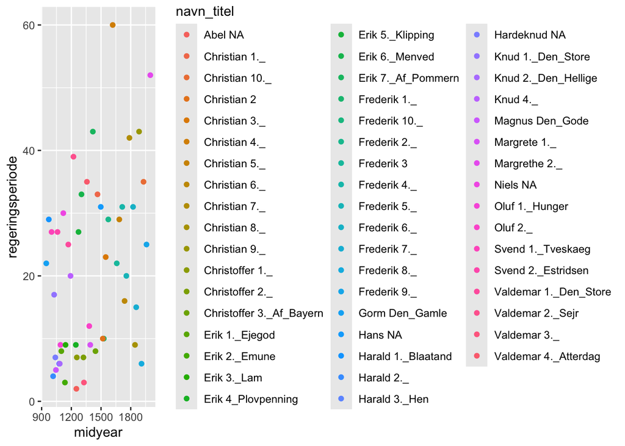

```r
# YOUR CODE
konger %>%
  mutate(midyear = Regerinsperiode_start_aar+regeringsperiode/2) %>%
  mutate(navn_titel = paste(Navn,Titel)) %>%
   ggplot(aes(x=midyear, y=regeringsperiode))+geom_point(aes(colour = navn_titel))
```